# Mako hSDM BRT explore (ROMS and CMEM domains)

Author

Emily Nazario

Published

February 1, 2024

On this document I start my initial exploration with the different model outputs, ranking of covariate influence, and projections. Here, I only explore BRT approaches, but later I may also explore and compare those from GAMMs. The hypotheses I would like to test with these models are as follows:

**H1:** The aerobic growth index (AGI) at deeper depths will have a larger relative influence on habitat suitability than the AGI values closer to the surface.

*study objective being met:* Understand how the AGI across depth layers influences habitat suitability. Are AGI values at deeper depths more influential? This would make sense given the reductions in oxygen availability and would be interesting given anticipated changes for the shoaling OMZ.

**H2:** The AGI will have important pairwise interactions with latitude and longitude.

*study objective being met:* Understand how the AGI moving towards the equator (theoretical thermal and metabolic edge for makos) and towards the coast (more shallow OMZs) may influence habitat suitability. Coastal areas in Baja are expected to be the regions that would be the first to become metabolically challenging under prediceted climate change scenarios.

**H3:** Models with the AGI as a covariate will have better predictive power than models with just dissolved oxygen and temperature.

*study objective being met:* Here, I am interested in understanding how model performance differs when AGI is a covariate relative to when DO and temperature are covariates. This will be an interesting feature to see what this physio-informed metric brings to the table for this study. Will it be informative? Or will the unique metabolic demands of mako sharks be underrepresented in this metric?

## CMEM Surface BRT w/ AGI

**tc5, lr0.01, bf0.75**

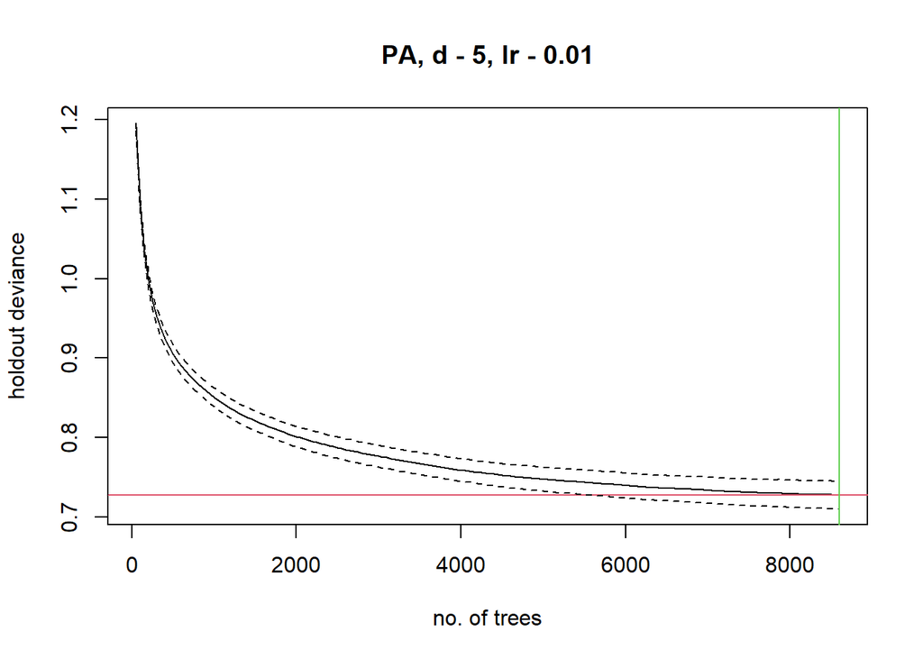

```r
#the tc, lr, and bag fraction values here are defaults. The number of trees are optimally selected by the model. I explore modified values elsewhere on this page.

#fit model
try(agi_tc5_lr01_bf75 <- dismo::gbm.step(data = dat_train,
                                    gbm.x = c(3:4, 9:15, 17, 18, 20),
                                    gbm.y = 5,
                                    family = "bernoulli",
                                    tree.complexity = 5,
                                    learning.rate = 0.01,
                                    bag.fraction = 0.75,
                                    silent = TRUE,
                                    plot.main = TRUE))
```

```r
ggBRT::ggPerformance(agi_tc5_lr01_bf75)
```

```
                     Model 1
Total.Deviance     1.3862932
Residual.Deviance  0.3206763
Correlation        0.9341755
AUC                0.9970000
Per.Expl          76.8680725
cvDeviance         0.7278063
cvCorrelation      0.7323428
cvAUC              0.9154000
cvPer.Expl        47.4998294
```

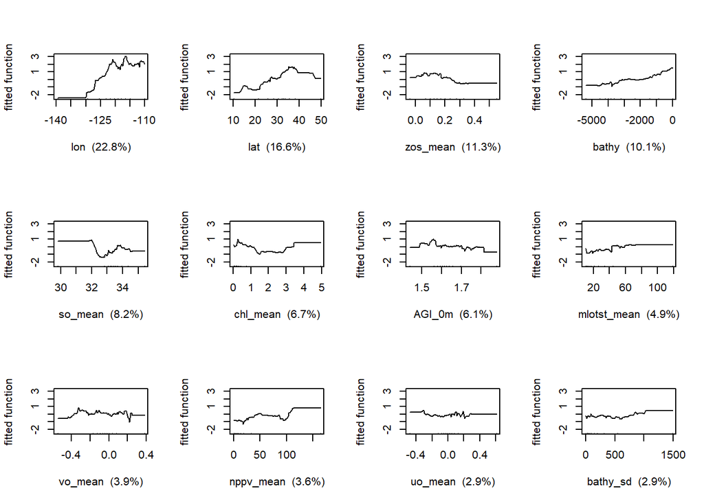

```r
#explore outputs
gbm.plot(agi_tc5_lr01_bf75, nplots = 12, plot.layout = c(3,4), write.title = FALSE)
```

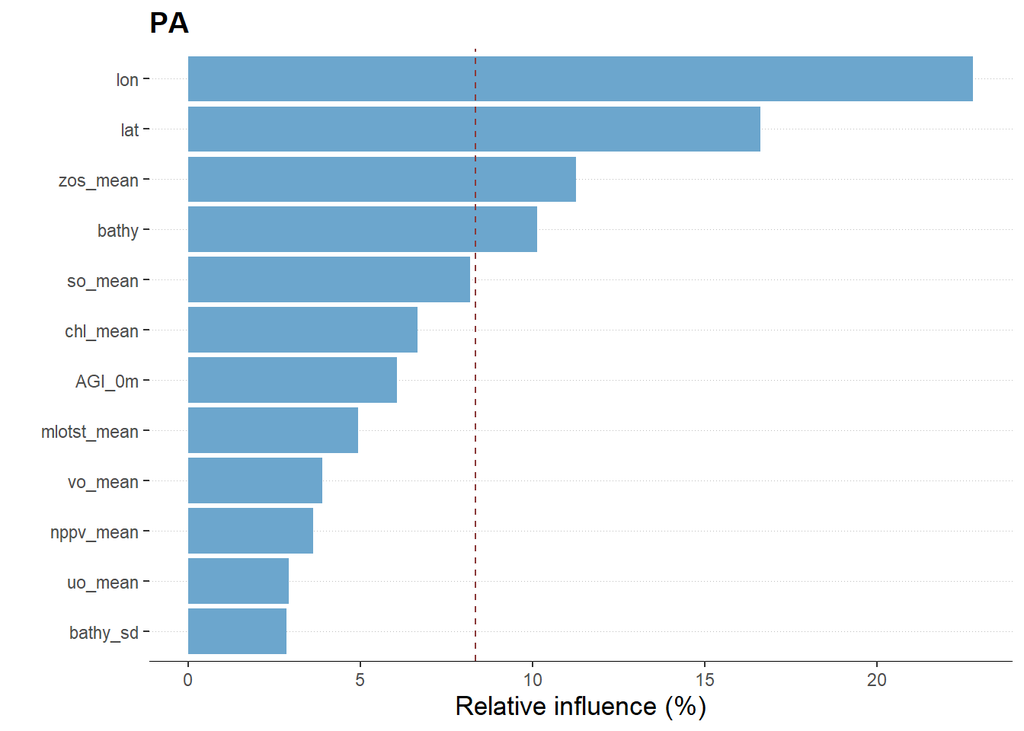

```
              rel.inf
lon         22.807607
lat         16.619085
zos_mean    11.270229
bathy       10.144607
so_mean      8.188130
chl_mean     6.664118
AGI_0m       6.056296
mlotst_mean  4.925860
vo_mean      3.904734
nppv_mean    3.627946
uo_mean      2.930661
bathy_sd     2.860727
```

```r
#relative influence of predictors
ggBRT::ggInfluence(agi_tc5_lr01_bf75)
```

```r
#find the 5 most important pairwise interactions
AGI_int <- gbm.interactions(agi_tc5_lr01_bf75)
AGI_int$rank.list
```

```
  var1.index  var1.names var2.index var2.names int.size
1          2         lat          1        lon   323.28
2          3     so_mean          1        lon   238.21
3         12      AGI_0m          7    vo_mean   180.67
4          4 mlotst_mean          3    so_mean   160.07
5         12      AGI_0m          1        lon   110.31
6          3     so_mean          2        lat   108.87
7         12      AGI_0m          2        lat    88.87
```

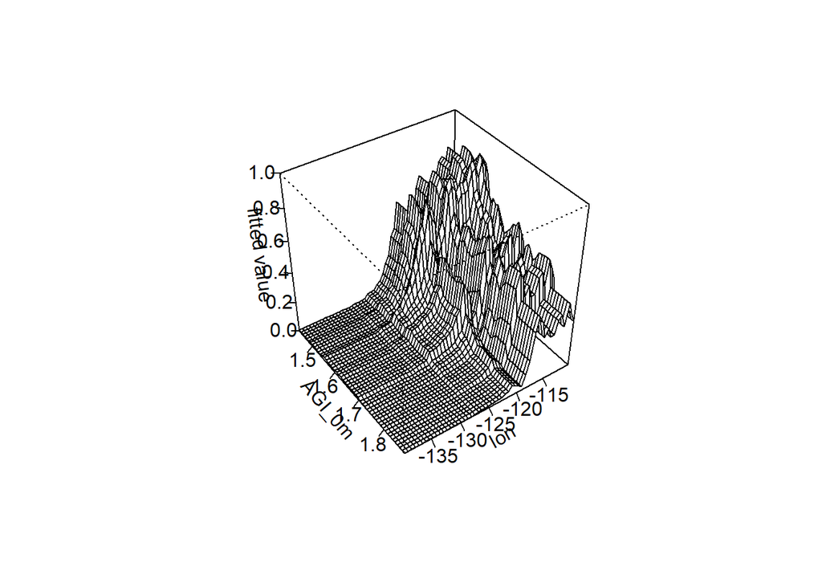

```r
#plot some interactions of interest...
gbm.perspec(agi_tc5_lr01_bf75, 12, 1)
```

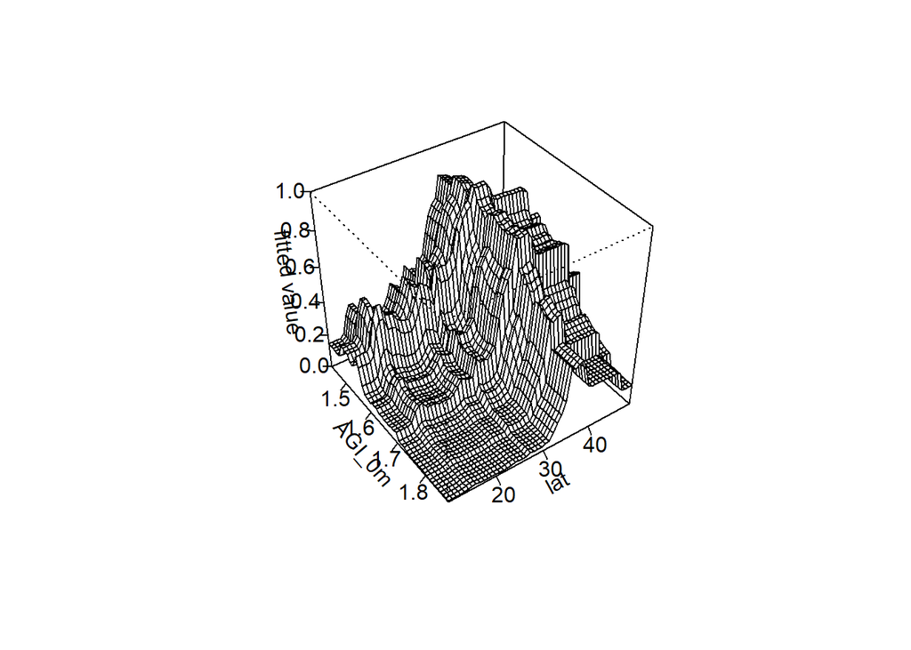

```r
gbm.perspec(agi_tc5_lr01_bf75, 12, 2)
```

```r
#predictions
preds <- predict.gbm(agi_tc5_lr01_bf75, dat_test,
                     n.trees = agi_tc5_lr01_bf75$gbm.call$best.trees,
                     type = "response")

tc5 <- calc.deviance(obs = dat_test$PA, preds)
lr01 <- calc.deviance(obs = dat_test$PA, preds)
tc5
```

```
[1] 0.4247015
```

```r
dat_pred <- cbind(dat_test$PA, preds)
pres <- dat_pred[dat_pred[,1] == 1, 2]
abs <- dat_pred[dat_pred[,1] == 0, 2]

evaluate(p = pres, a = abs)
```

```
class          : ModelEvaluation
n presences    : 934
n absences     : 922
AUC            : 0.9806113
cor            : 0.8857674
max TPR+TNR at : 0.4697504
```

```r
#### spatial prediction -- still in progress ##

#cmem_nc0 <- rast(here("data/enviro/CMEMS/processed/CMEM_SST_SAL_MLD_SSH_UO_VO_CHL_NPP_DO_0m_Jan2004_Dec2009_0.25_D.nc"))

  #randomly sample 3 days to plot habitat suitability
# sample(1:2192, 3) #2004-10-07, 2008-04-11, 2009-10-20
# r2004 <- cmem_nc0[[time(cmem_nc0) == as.Date("2004-10-07")]]
# r2008 <- cmem_nc0[[time(cmem_nc0) == as.Date("2008-04-11")]]
# r2009 <- cmem_nc0[[time(cmem_nc0) == as.Date("2009-10-20")]]
```

**tc5, lr0.01, bf0.5**

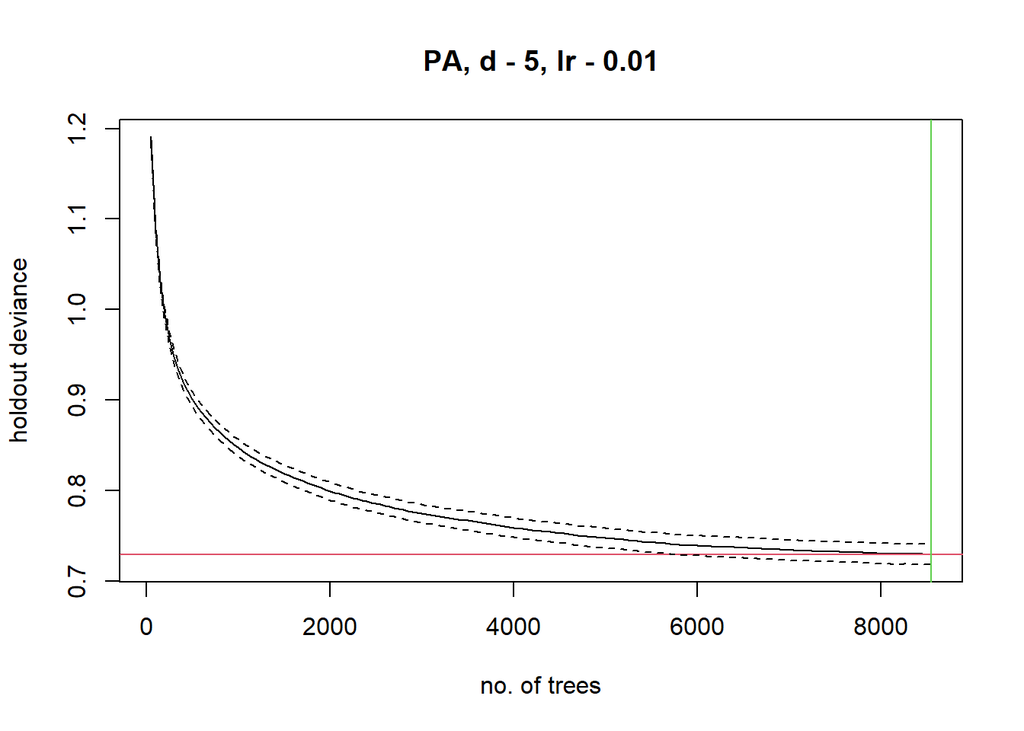

```r
#the tc, lr, and bag fraction values here are defaults. The number of trees are optimally selected by the model. I explore modified values elsewhere on this page.

#fit model
try(agi_tc5_lr01_bf5 <- dismo::gbm.step(data = dat_train,
                                    gbm.x = c(3:4, 9:15, 17, 18, 20),
                                    gbm.y = 5,
                                    family = "bernoulli",
                                    tree.complexity = 5,
                                    learning.rate = 0.01,
                                    bag.fraction = 0.5,
                                    silent = TRUE,
                                    plot.main = TRUE))
```

```r
ggBRT::ggPerformance(agi_tc5_lr01_bf5)
```

```
                     Model 1
Total.Deviance     1.3862932
Residual.Deviance  0.3304797
Correlation        0.9292598
AUC                0.9963000
Per.Expl          76.1609071
cvDeviance         0.7292912
cvCorrelation      0.7304756
cvAUC              0.9146400
cvPer.Expl        47.3927132
```

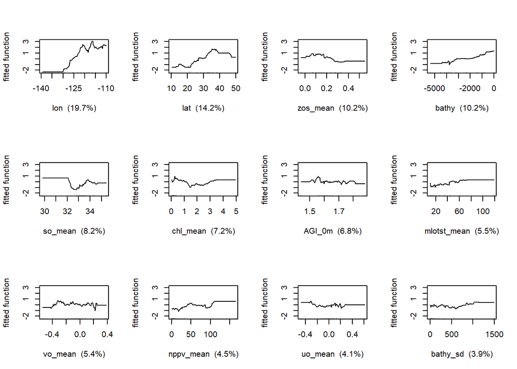

```r
#explore outputs
gbm.plot(agi_tc5_lr01_bf5, nplots = 12, plot.layout = c(3,4), write.title = FALSE)
```

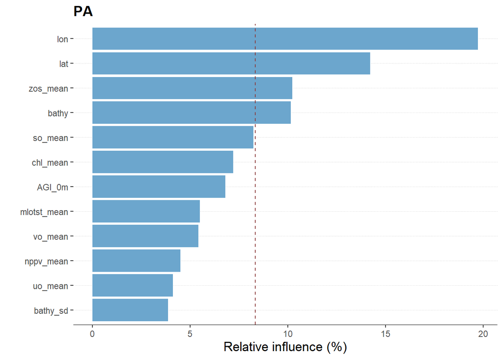

```
              rel.inf
lon         19.744938
lat         14.214639
zos_mean    10.235890
bathy       10.160590
so_mean      8.244938
chl_mean     7.197906
AGI_0m       6.798024
mlotst_mean  5.489021
vo_mean      5.417660
nppv_mean    4.506641
uo_mean      4.122173
bathy_sd     3.867579
```

```r
#relative influence of predictors
ggBRT::ggInfluence(agi_tc5_lr01_bf5)
```

```r
#find the 5 most important pairwise interactions
AGI_int <- gbm.interactions(agi_tc5_lr01_bf5)
AGI_int$rank.list
```

```
  var1.index  var1.names var2.index var2.names int.size
1          2         lat          1        lon   344.15
2          3     so_mean          1        lon   290.43
3         12      AGI_0m          7    vo_mean   162.99
4          4 mlotst_mean          3    so_mean   123.98
5         12      AGI_0m          1        lon    88.07
6         12      AGI_0m          2        lat    78.98
7          3     so_mean          2        lat    75.19
```

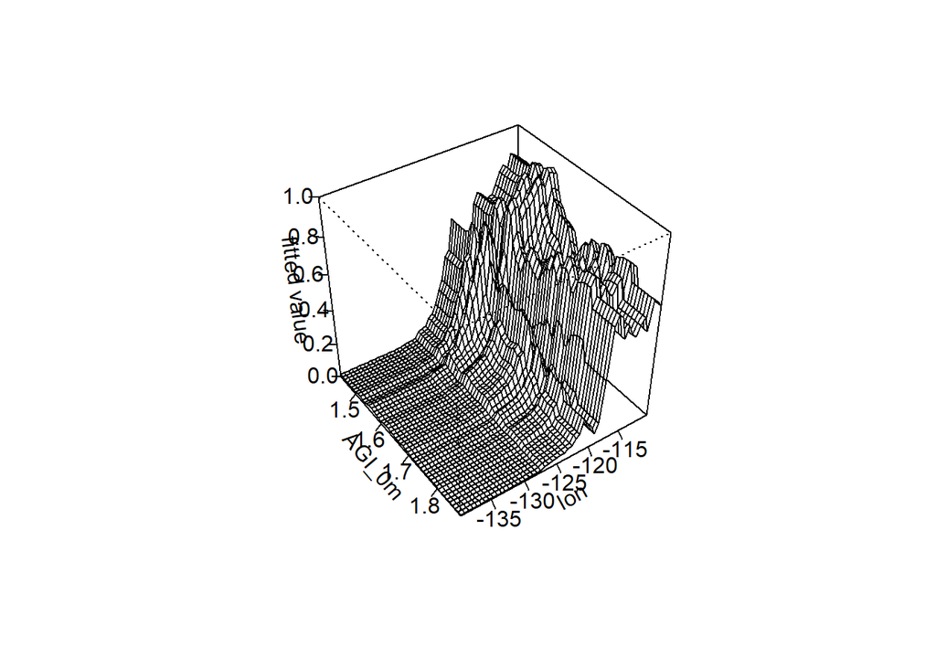

```r
#plot some interactions of interest...
gbm.perspec(agi_tc5_lr01_bf5, 12, 1)
```

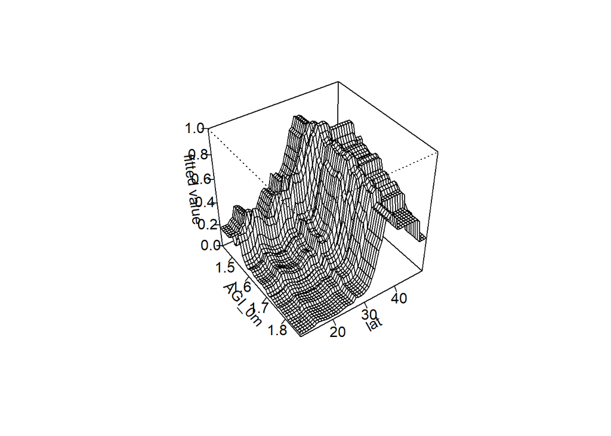

```r
gbm.perspec(agi_tc5_lr01_bf5, 12, 2)
```

```r
#predictions
preds <- predict.gbm(agi_tc5_lr01_bf5, dat_test,
                     n.trees = agi_tc5_lr01_bf5$gbm.call$best.trees,
                     type = "response")

calc.deviance(obs = dat_test$PA, preds)
```

```
[1] 0.4308628
```

```r
dat_pred <- cbind(dat_test$PA, preds)
pres <- dat_pred[dat_pred[,1] == 1, 2]
abs <- dat_pred[dat_pred[,1] == 0, 2]

evaluate(p = pres, a = abs)
```

```
class          : ModelEvaluation
n presences    : 934
n absences     : 922
AUC            : 0.9800807
cor            : 0.8822659
max TPR+TNR at : 0.5405467
```

**tc2, lr0.01, bf0.75**

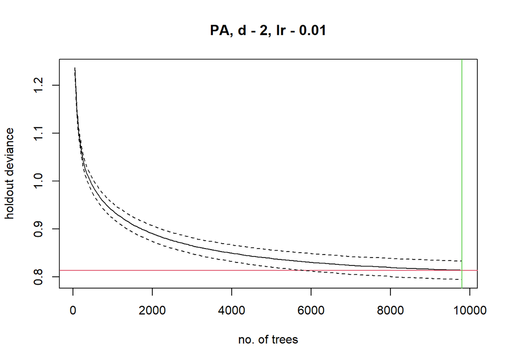

```r
#the tc, lr, and bag fraction values here are defaults. The number of trees are optimally selected by the model. I explore modified values elsewhere on this page.

#fit model
try(agi_tc2_lr01 <- dismo::gbm.step(data = dat_train,
                                    gbm.x = c(3:4, 9:15, 17, 18, 20),
                                    gbm.y = 5,
                                    family = "bernoulli",
                                    tree.complexity = 2,
                                    learning.rate = 0.01,
                                    bag.fraction = 0.75,
                                    silent = TRUE,
                                    plot.main = TRUE))
```

```r
ggBRT::ggPerformance(agi_tc2_lr01)
```

```
                     Model 1
Total.Deviance     1.3862932
Residual.Deviance  0.6066518
Correlation        0.8054341
AUC                0.9535000
Per.Expl          56.2392840
cvDeviance         0.8138384
cvCorrelation      0.6886480
cvAUC              0.8922100
cvPer.Expl        41.2939175
```

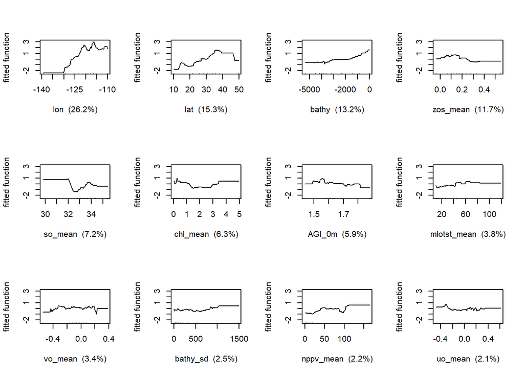

```r
#explore outputs
gbm.plot(agi_tc2_lr01, nplots = 12, plot.layout = c(3,4), write.title = FALSE)
```

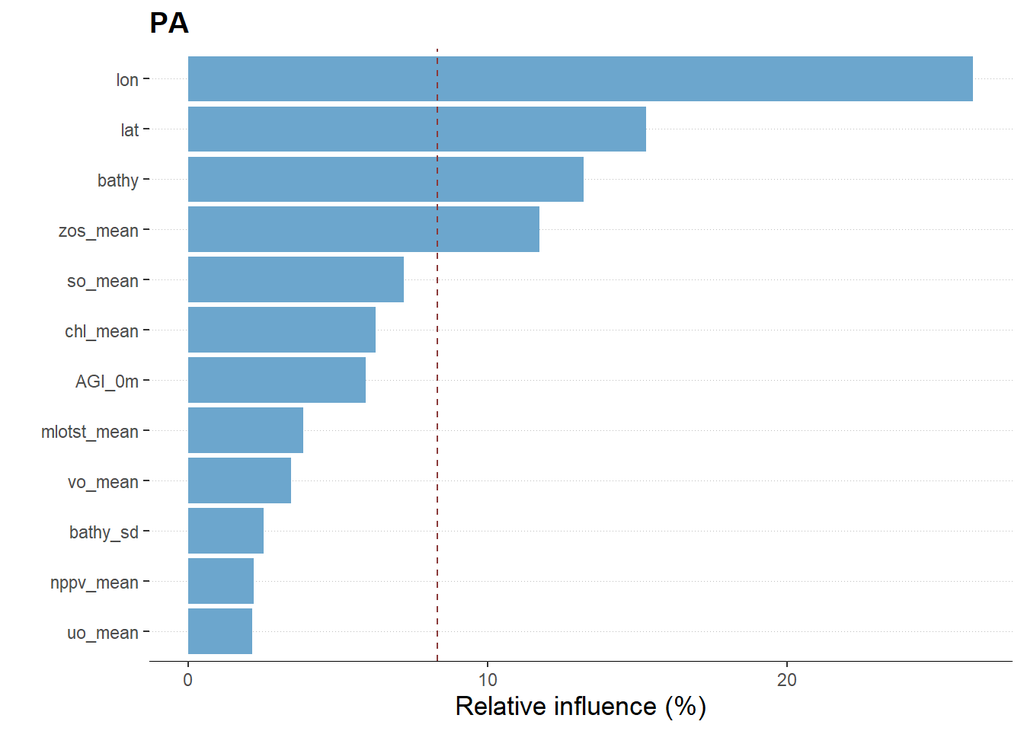

```
              rel.inf
lon         26.233192
lat         15.304185
bathy       13.211563
zos_mean    11.746137
so_mean      7.215980
chl_mean     6.254369
AGI_0m       5.917993
mlotst_mean  3.841918
vo_mean      3.440513
bathy_sd     2.508625
nppv_mean    2.176929
uo_mean      2.148596
```

```r
#relative influence of predictors
ggBRT::ggInfluence(agi_tc2_lr01)
```

```r
#find the 2 most important pairwise interactions
AGI_int <- gbm.interactions(agi_tc2_lr01)
AGI_int$rank.list
```

```
  var1.index var1.names var2.index var2.names int.size
1          2        lat          1        lon   185.93
2          3    so_mean          2        lat   132.12
3         12     AGI_0m          7    vo_mean   121.38
4          3    so_mean          1        lon   108.01
5         12     AGI_0m          3    so_mean    72.42
6         12     AGI_0m          1        lon    68.35
7          8   chl_mean          1        lon    56.73
```

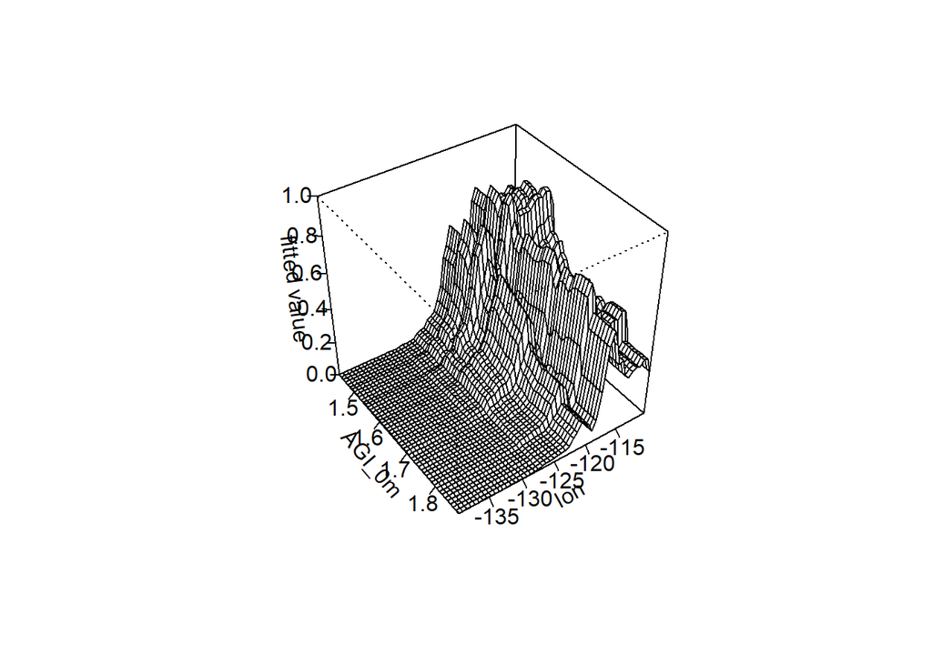

```r
#plot some interactions of interest...
gbm.perspec(agi_tc2_lr01, 12, 1)
```

```r
#gbm.perspec(agi_tc5_lr01_bf5, 12, 2)

#predictions
preds <- predict.gbm(agi_tc2_lr01, dat_test,
                     n.trees = agi_tc2_lr01$gbm.call$best.trees,
                     type = "response")

tc2 <- calc.deviance(obs = dat_test$PA, preds)
tc2
```

```
[1] 0.6704117
```

```r
dat_pred <- cbind(dat_test$PA, preds)
pres <- dat_pred[dat_pred[,1] == 1, 2]
abs <- dat_pred[dat_pred[,1] == 0, 2]

evaluate(p = pres, a = abs)
```

```
class          : ModelEvaluation
n presences    : 934
n absences     : 922
AUC            : 0.9355877
cor            : 0.7693581
max TPR+TNR at : 0.5861651
```

**tc7, lr0.01, bf0.75**

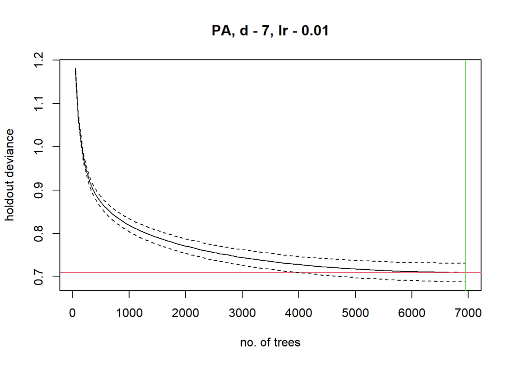

```r
#fit model
try(agi_tc7_lr01 <- dismo::gbm.step(data = dat_train,
                                    gbm.x = c(3:4, 9:15, 17, 18, 20),
                                    gbm.y = 5,
                                    family = "bernoulli",
                                    tree.complexity = 7,
                                    learning.rate = 0.01,
                                    bag.fraction = 0.75,
                                    silent = TRUE,
                                    plot.main = TRUE))
```

```r
ggBRT::ggPerformance(agi_tc7_lr01)
```

```
                     Model 1
Total.Deviance     1.3862932
Residual.Deviance  0.2702321
Correlation        0.9521035
AUC                0.9990000
Per.Expl          80.5068564
cvDeviance         0.7098020
cvCorrelation      0.7414554
cvAUC              0.9195500
cvPer.Expl        48.7985659
```

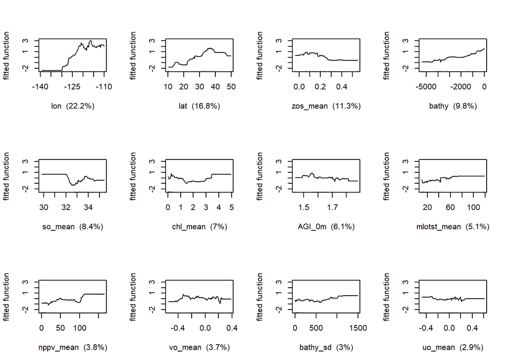

```r
#explore outputs
gbm.plot(agi_tc7_lr01, nplots = 12, plot.layout = c(3,4), write.title = FALSE)
```

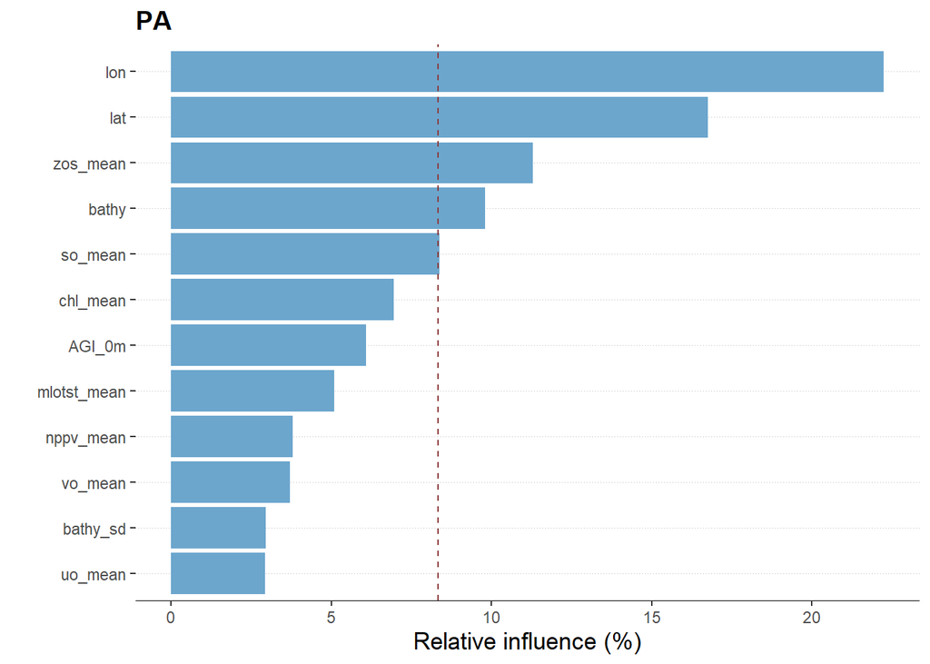

```
              rel.inf
lon         22.247444
lat         16.764011
zos_mean    11.283529
bathy        9.790897
so_mean      8.366102
chl_mean     6.953794
AGI_0m       6.083258
mlotst_mean  5.087663
nppv_mean    3.799827
vo_mean      3.722055
bathy_sd     2.967107
uo_mean      2.934314
```

```r
#relative influence of predictors
ggBRT::ggInfluence(agi_tc7_lr01)
```

```r
#find the 5 most important pairwise interactions
AGI_int <- gbm.interactions(agi_tc7_lr01)
AGI_int$rank.list
```

```
  var1.index  var1.names var2.index var2.names int.size
1          3     so_mean          1        lon   406.88
2          2         lat          1        lon   319.36
3          4 mlotst_mean          3    so_mean   253.79
4         12      AGI_0m          7    vo_mean   168.84
5          5    zos_mean          3    so_mean   130.99
6         12      AGI_0m          2        lat   107.80
7          3     so_mean          2        lat   105.55
```

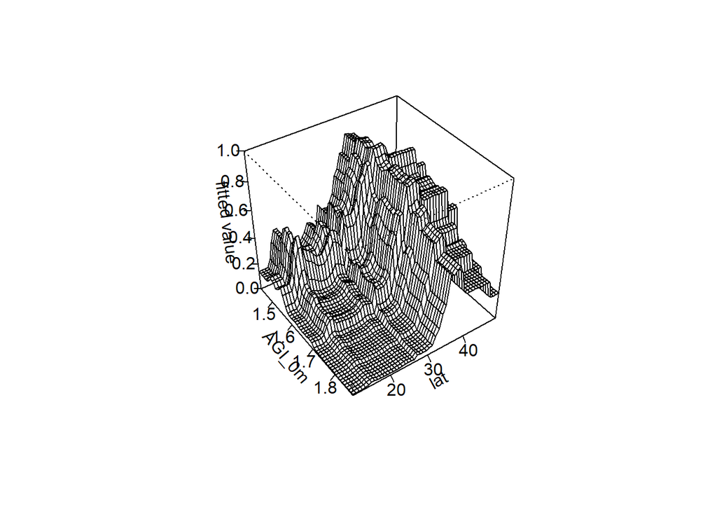

```r
#plot some interactions of interest...
#gbm.perspec(agi_tc7_lr01, 12, 1)
gbm.perspec(agi_tc7_lr01, 12, 2)
```

```r
#predictions
preds <- predict.gbm(agi_tc7_lr01, dat_test,
                     n.trees = agi_tc7_lr01$gbm.call$best.trees,
                     type = "response")

tc7 <- calc.deviance(obs = dat_test$PA, preds)
tc7
```

```
[1] 0.3790708
```

```r
dat_pred <- cbind(dat_test$PA, preds)
pres <- dat_pred[dat_pred[,1] == 1, 2]
abs <- dat_pred[dat_pred[,1] == 0, 2]

evaluate(p = pres, a = abs)
```

```
class          : ModelEvaluation
n presences    : 934
n absences     : 922
AUC            : 0.9846304
cor            : 0.9033489
max TPR+TNR at : 0.5238002
```

**tc10, lr0.01, bf0.75**

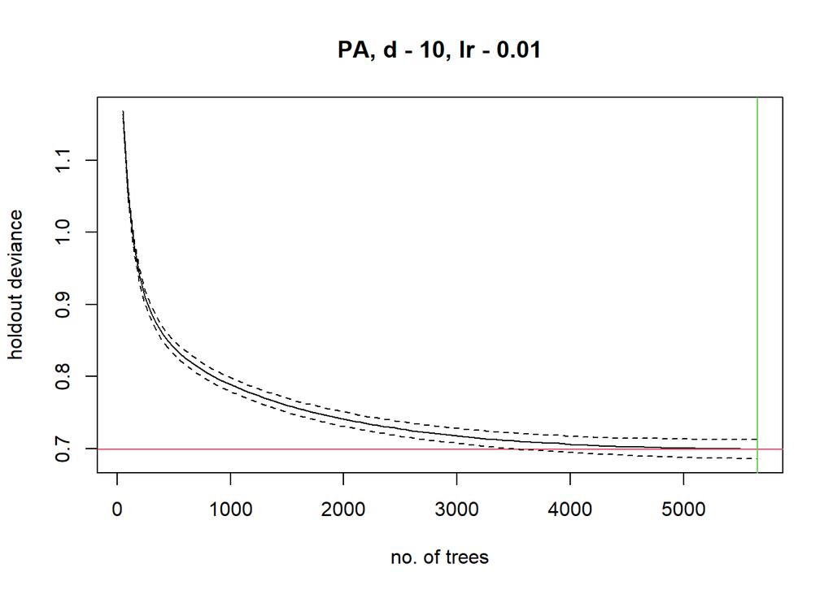

```r
#fit model
try(agi_tc10_lr01 <- dismo::gbm.step(data = dat_train,
                                    gbm.x = c(3:4, 9:15, 17, 18, 20),
                                    gbm.y = 5,
                                    family = "bernoulli",
                                    tree.complexity = 10,
                                    learning.rate = 0.01,
                                    bag.fraction = 0.75,
                                    silent = TRUE,
                                    plot.main = TRUE))
```

```r
ggBRT::ggPerformance(agi_tc10_lr01)
```

```
                     Model 1
Total.Deviance     1.3862932
Residual.Deviance  0.2216519
Correlation        0.9671251
AUC                0.9998000
Per.Expl          84.0111843
cvDeviance         0.6994314
cvCorrelation      0.7464269
cvAUC              0.9227000
cvPer.Expl        49.5466490
```

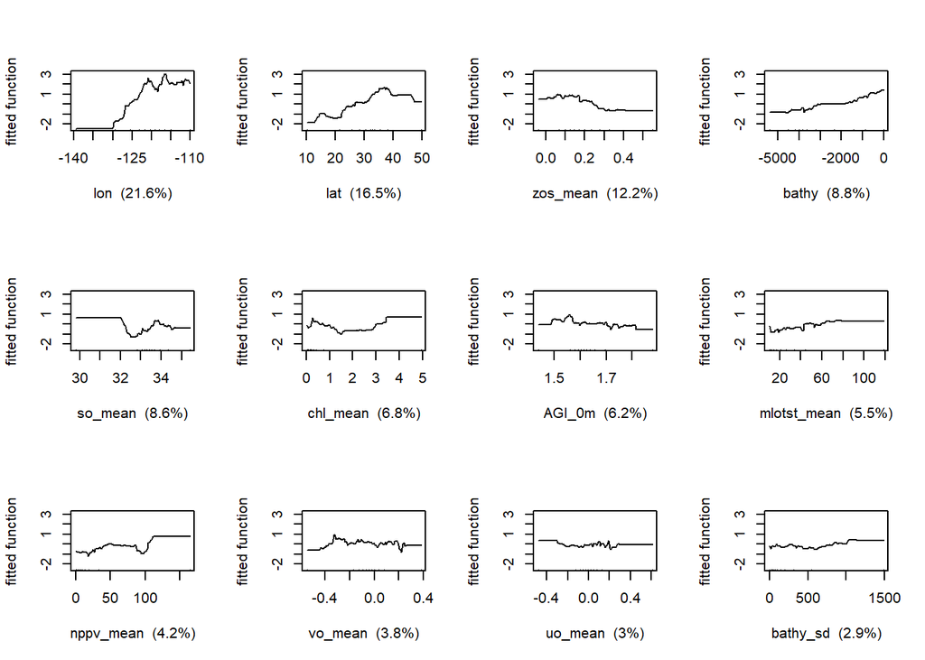

```r
#explore outputs
gbm.plot(agi_tc10_lr01, nplots = 12, plot.layout = c(3,4), write.title = FALSE)
```

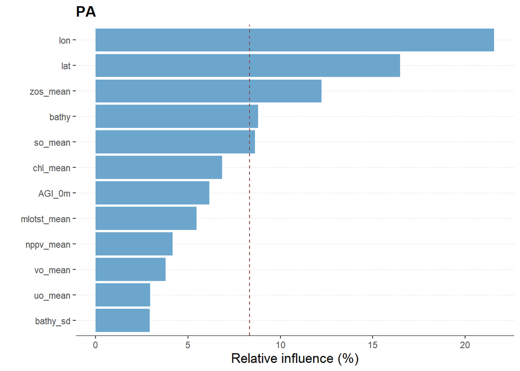

```
              rel.inf
lon         21.575284
lat         16.476767
zos_mean    12.224158
bathy        8.803764
so_mean      8.633456
chl_mean     6.842367
AGI_0m       6.163116
mlotst_mean  5.463037
nppv_mean    4.166699
vo_mean      3.778571
uo_mean      2.952780
bathy_sd     2.919999
```

```r
#relative influence of predictors
ggBRT::ggInfluence(agi_tc10_lr01)
```

```r
#find the 5 most important pairwise interactions
AGI_int <- gbm.interactions(agi_tc10_lr01)
AGI_int$rank.list
```

```
  var1.index  var1.names var2.index var2.names int.size
1          3     so_mean          1        lon   460.49
2          2         lat          1        lon   336.77
3          4 mlotst_mean          3    so_mean   276.34
4         12      AGI_0m          7    vo_mean   147.92
5          5    zos_mean          3    so_mean   106.61
6         12      AGI_0m          2        lat    86.65
7          5    zos_mean          1        lon    85.60
```

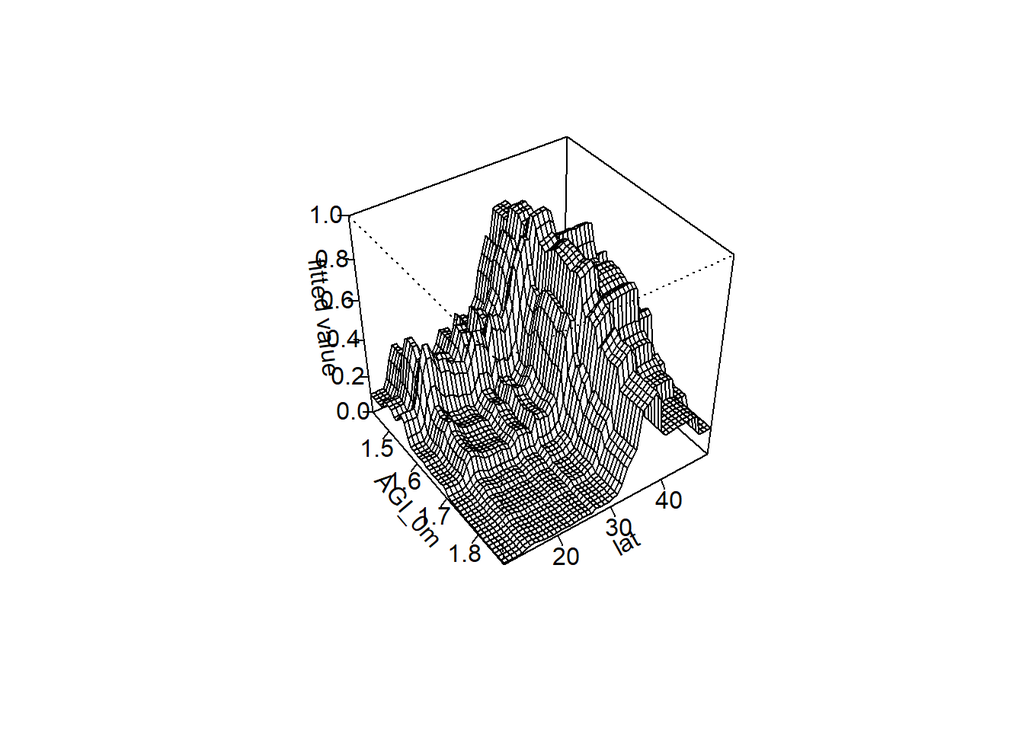

```r
#plot some interactions of interest...
#gbm.perspec(agi_tc10_lr01, 12, 1)
gbm.perspec(agi_tc10_lr01, 12, 2)
```

```r
#predictions
preds <- predict.gbm(agi_tc10_lr01, dat_test,
                     n.trees = agi_tc10_lr01$gbm.call$best.trees,
                     type = "response")

tc10 <- calc.deviance(obs = dat_test$PA, preds)
tc10
```

```
[1] 0.3381319
```

```r
dat_pred <- cbind(dat_test$PA, preds)
pres <- dat_pred[dat_pred[,1] == 1, 2]
abs <- dat_pred[dat_pred[,1] == 0, 2]

evaluate(p = pres, a = abs)
```

```
class          : ModelEvaluation
n presences    : 934
n absences     : 922
AUC            : 0.9870481
cor            : 0.917138
max TPR+TNR at : 0.5292519
```

**tc5, lr0.05, bf0.75**

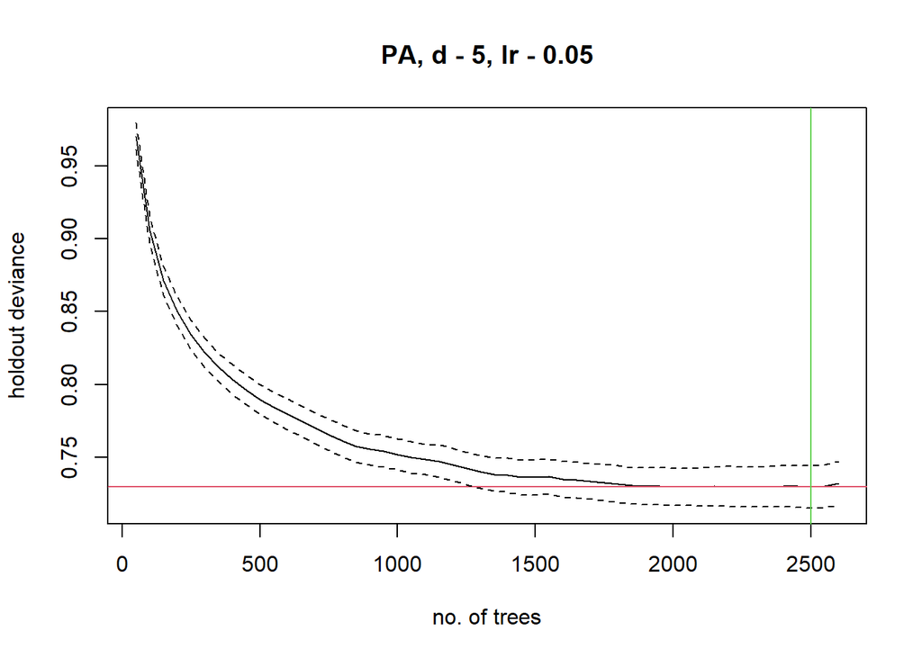

```r
#the tc, lr, and bag fraction values here are defaults. The number of trees are optimally selected by the model. I explore modified values elsewhere on this page.

#fit model
try(agi_tc5_lr05 <- dismo::gbm.step(data = dat_train,
                                    gbm.x = c(3:4, 9:15, 17, 18, 20),
                                    gbm.y = 5,
                                    family = "bernoulli",
                                    tree.complexity = 5,
                                    learning.rate = 0.05,
                                    bag.fraction = 0.75,
                                    silent = TRUE,
                                    plot.main = TRUE))
```

```r
ggBRT::ggPerformance(agi_tc5_lr05)
```

```
                     Model 1
Total.Deviance     1.3862932
Residual.Deviance  0.2302159
Correlation        0.9622571
AUC                0.9996000
Per.Expl          83.3934171
cvDeviance         0.7295750
cvCorrelation      0.7366317
cvAUC              0.9172400
cvPer.Expl        47.3722430
```

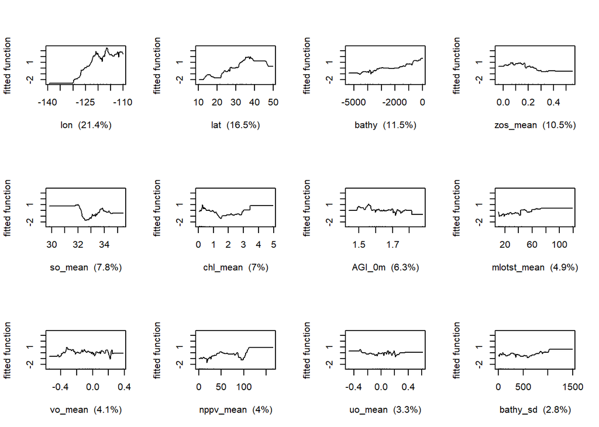

```r
#explore outputs
gbm.plot(agi_tc5_lr05, nplots = 12, plot.layout = c(3,4), write.title = FALSE)
```

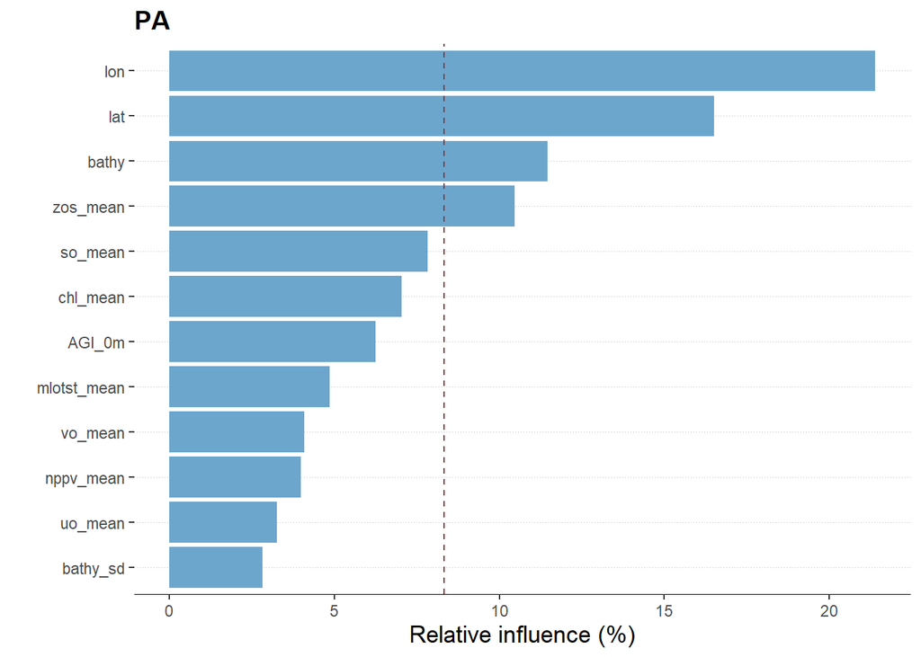

```
              rel.inf
lon         21.397751
lat         16.505666
bathy       11.471714
zos_mean    10.473476
so_mean      7.835786
chl_mean     7.037222
AGI_0m       6.259803
mlotst_mean  4.859576
vo_mean      4.082482
nppv_mean    3.987540
uo_mean      3.262288
bathy_sd     2.826696
```

```r
#relative influence of predictors
ggBRT::ggInfluence(agi_tc5_lr05)
```

```r
#find the 5 most important pairwise interactions
AGI_int <- gbm.interactions(agi_tc5_lr05)
AGI_int$rank.list
```

```
  var1.index  var1.names var2.index var2.names int.size
1          2         lat          1        lon   487.11
2          3     so_mean          1        lon   349.85
3          4 mlotst_mean          3    so_mean   271.05
4         12      AGI_0m          7    vo_mean   235.44
5         12      AGI_0m          2        lat   152.96
6          3     so_mean          2        lat   137.81
7         12      AGI_0m          1        lon   130.38
```

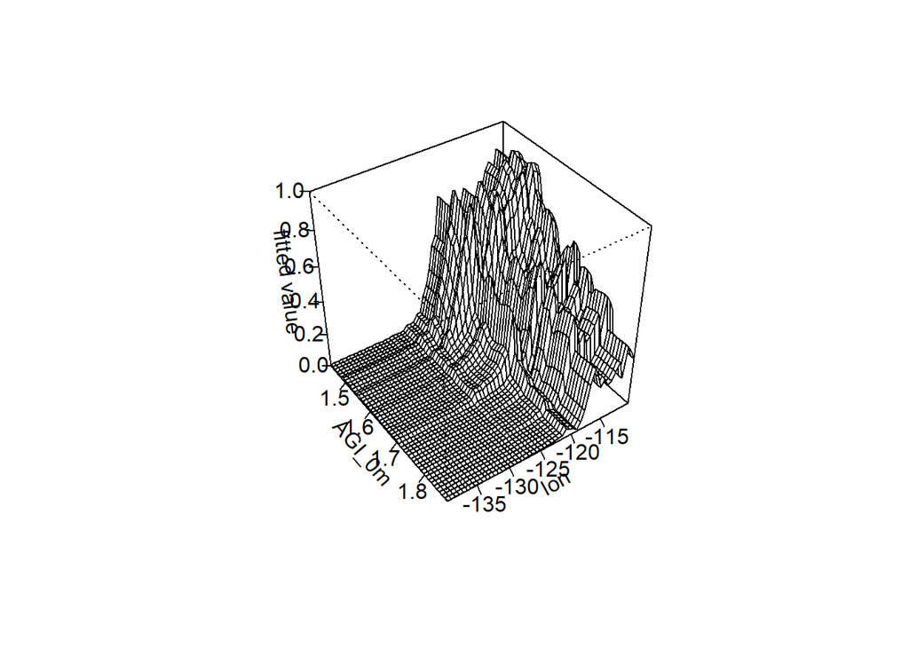

```r
#plot some interactions of interest...
gbm.perspec(agi_tc5_lr05, 12, 1)
```

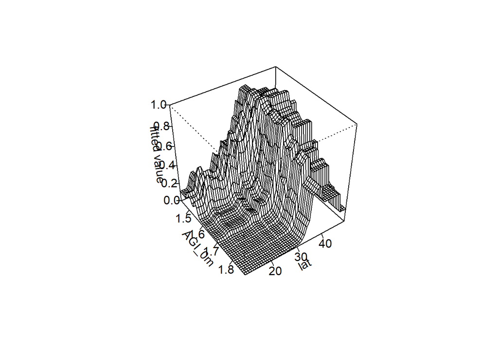

```r
gbm.perspec(agi_tc5_lr05, 12, 2)
```

```r
#predictions
preds <- predict.gbm(agi_tc5_lr05, dat_test,
                     n.trees = agi_tc5_lr05$gbm.call$best.trees,
                     type = "response")

lr05 <- calc.deviance(obs = dat_test$PA, preds)
lr05
```

```
[1] 0.3559129
```

```r
dat_pred <- cbind(dat_test$PA, preds)
pres <- dat_pred[dat_pred[,1] == 1, 2]
abs <- dat_pred[dat_pred[,1] == 0, 2]

evaluate(p = pres, a = abs)
```

```
class          : ModelEvaluation
n presences    : 934
n absences     : 922
AUC            : 0.9845596
cor            : 0.9079683
max TPR+TNR at : 0.5260323
```

**tc5, lr0.1, bf0.75**

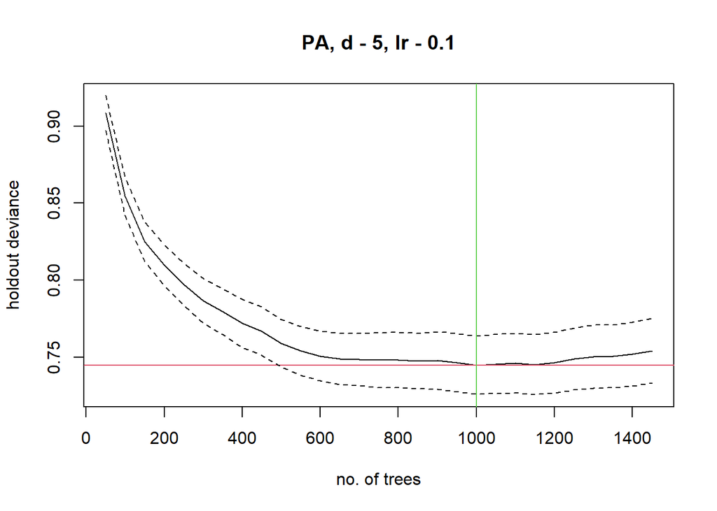

```r
#the tc, lr, and bag fraction values here are defaults. The number of trees are optimally selected by the model. I explore modified values elsewhere on this page.

#fit model
try(agi_tc5_lr1 <- dismo::gbm.step(data = dat_train,
                                    gbm.x = c(3:4, 9:15, 17, 18, 20),
                                    gbm.y = 5,
                                    family = "bernoulli",
                                    tree.complexity = 5,
                                    learning.rate = 0.1,
                                    bag.fraction = 0.75,
                                    silent = TRUE,
                                    plot.main = TRUE))
```

```r
ggBRT::ggPerformance(agi_tc5_lr1)
```

```
                     Model 1
Total.Deviance     1.3862932
Residual.Deviance  0.2795583
Correlation        0.9460023
AUC                0.9983000
Per.Expl          79.8341135
cvDeviance         0.7449238
cvCorrelation      0.7272858
cvAUC              0.9122400
cvPer.Expl        46.2650585
```

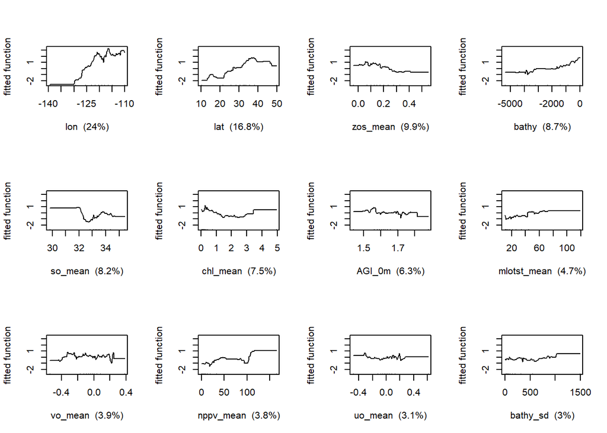

```r
#explore outputs
gbm.plot(agi_tc5_lr1, nplots = 12, plot.layout = c(3,4), write.title = FALSE)
```

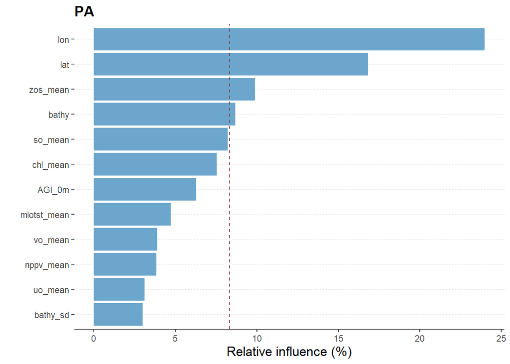

```
              rel.inf
lon         23.977009
lat         16.825828
zos_mean     9.898718
bathy        8.674721
so_mean      8.219812
chl_mean     7.534334
AGI_0m       6.292896
mlotst_mean  4.725103
vo_mean      3.887165
nppv_mean    3.834130
uo_mean      3.127480
bathy_sd     3.002805
```

```r
#relative influence of predictors
ggBRT::ggInfluence(agi_tc5_lr1)
```

```r
#find the 5 most important pairwise interactions
AGI_int <- gbm.interactions(agi_tc5_lr1)
AGI_int$rank.list
```

```
  var1.index  var1.names var2.index var2.names int.size
1          2         lat          1        lon   442.54
2         12      AGI_0m          7    vo_mean   364.81
3          3     so_mean          1        lon   240.62
4          4 mlotst_mean          3    so_mean   200.27
5          3     so_mean          2        lat   199.61
6          5    zos_mean          3    so_mean   181.62
7          4 mlotst_mean          1        lon   122.84
```